# Self-Driving Car Engineer Nanodegree

## Topic : Deep Learning

## Project : Traffic Sign Recognition Classifier

## Dataset Exploration

```python
#Imports
%matplotlib inline
import matplotlib.pyplot as plt
import numpy as np
import tensorflow as tf
from tensorflow.contrib.layers import flatten
import pickle
import csv
import collections
from sklearn.preprocessing import OneHotEncoder
from sklearn.metrics import confusion_matrix
from sklearn.cross_validation import train_test_split
import time
from datetime import timedelta
import math
import cv2
import matplotlib.gridspec as gridspec
import os
import random
```

```python
# Load pickled data
TrainingFile = "../traffic-signs-data/train.p"
TestingFile  = "../traffic-signs-data/test.p"
LabelsFile   = "../traffic-signs-data/signnames.csv"
with open(TrainingFile, mode='rb') as f:
    TrainingData = pickle.load(f)
with open(TestingFile, mode='rb') as f:
    TestingData = pickle.load(f)
with open(LabelsFile,mode='r') as csvfile:
    csvreader=csv.reader(csvfile)
    Labels=list(csvreader)
#Load into Arrays
TrainFeatures, TrainLabels = TrainingData['features'], TrainingData['labels']
TestFeatures , TestLabels  = TestingData['features'] , TestingData['labels']
```

```
German Traffic Signs- Data Set Details
Number of training examples = 39209
Number of testing  examples = 12630
Number of classes           = 43
Max # of Signs              = 2250 with label Speed limit (50km/h)
Min # of Signs              = 210  with label Speed limit (20km/h)
```

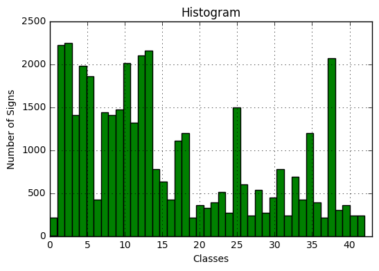

```python
# Number of training,testing examples and classes
NumTrainSam = len(TrainFeatures)
NumTestSam  = len(TestFeatures)
NumClasses  = len(Labels)
#Data Exploration
#1. Count number of images in each class
ClassCount=collections.Counter(TrainLabels)
#2. Min and Max Signs
maxkey=max(ClassCount,key=ClassCount.get) # Index with max number of signs
minkey=min(ClassCount,key=ClassCount.get) # Index with min number of signs
maxnum=ClassCount[maxkey]
minnum=ClassCount[minkey]
#Convert to list. ClassList has number of images for each class
ClassList=[]
for key, values in ClassCount.items():
    ClassList.append(values)
#Print the details
print("German Traffic Signs- Data Set Details")
print("Number of training examples =", NumTrainSam)
print("Number of testing  examples =", NumTestSam)
print("Number of classes           =", NumClasses)
print("Max # of Signs              = "+str(maxnum)+" with label "+str(Labels[maxkey][1]))
print("Min # of Signs              = "+str(minnum)+"  with label "+str(Labels[minkey][1]))

#Plot the histogram
plt.figure()
plt.title('Histogram')
plt.xlabel('Classes')
plt.ylabel('Number of Signs')
plt.grid(True)
plt.axis([0,NumClasses,0,2500])
n, bins, patches = plt.hist(TrainLabels, NumClasses ,facecolor='green')
```

```python
#Calculate data that needs to be generated and store it in ToGenNum list
ToGenNum=[]
#Print all classes
print("\n{:<55}{:<10}{:>20}".format("Traffic Sign","In Dataset","To be Generated"))
for i in range(0,NumClasses):
    String=str("{:<55}".format(Labels[i][1]))+"{:<10}".format(str(ClassList[i]))\
    +"{:>20}".format(str(maxnum-ClassList[i]))
    print(String)
    ToGenNum.append(maxnum-ClassList[i])

TotalNewData2Gen=sum(ToGenNum)
TotalDataSize=NumTrainSam+TotalNewData2Gen
print("\nTotal Data to be generated: "+str(TotalNewData2Gen))
print("Size of Total Dataset after new data is generated: "+str(TotalDataSize))
```

```
Traffic Sign                                           In Dataset     To be Generated
Speed limit (20km/h)                                   210                       2040
Speed limit (30km/h)                                   2220                        30
Speed limit (50km/h)                                   2250                         0
Speed limit (60km/h)                                   1410                       840
Speed limit (70km/h)                                   1980                       270
Speed limit (80km/h)                                   1860                       390
End of speed limit (80km/h)                            420                       1830
Speed limit (100km/h)                                  1440                       810
Speed limit (120km/h)                                  1410                       840
No passing                                             1470                       780
No passing for vechiles over 3.5 metric tons           2010                       240
Right-of-way at the next intersection                  1320                       930
Priority road                                          2100                       150
Yield                                                  2160                        90
Stop                                                   780                       1470
No vechiles                                            630                       1620
Vechiles over 3.5 metric tons prohibited               420                       1830
No entry                                               1110                      1140
General caution                                        1200                      1050
Dangerous curve to the left                            210                       2040
Dangerous curve to the right                           360                       1890
Double curve                                           330                       1920
Bumpy road                                             390                       1860
Slippery road                                          510                       1740
Road narrows on the right                              270                       1980
Road work                                              1500                       750
Traffic signals                                        600                       1650
Pedestrians                                            240                       2010
Children crossing                                      540                       1710
Bicycles crossing                                      270                       1980
Beware of ice/snow                                     450                       1800
Wild animals crossing                                  780                       1470
End of all speed and passing limits                    240                       2010
Turn right ahead                                       689                       1561
Turn left ahead                                        420                       1830
Ahead only                                             1200                      1050
Go straight or right                                   390                       1860
Go straight or left                                    210                       2040
Keep right                                             2070                       180
Keep left                                              300                       1950
Roundabout mandatory                                   360                       1890
End of no passing                                      240                       2010
End of no passing by vechiles over 3.5 metric tons     240                       2010

Total Data to be generated: 57541
Size of Total Dataset after new data is generated: 96750
```

```python
#Idea is to generate same random numbers so we can compare results after preprocessing
RandState=random.getstate() #Store randstate to get same results everytime
```

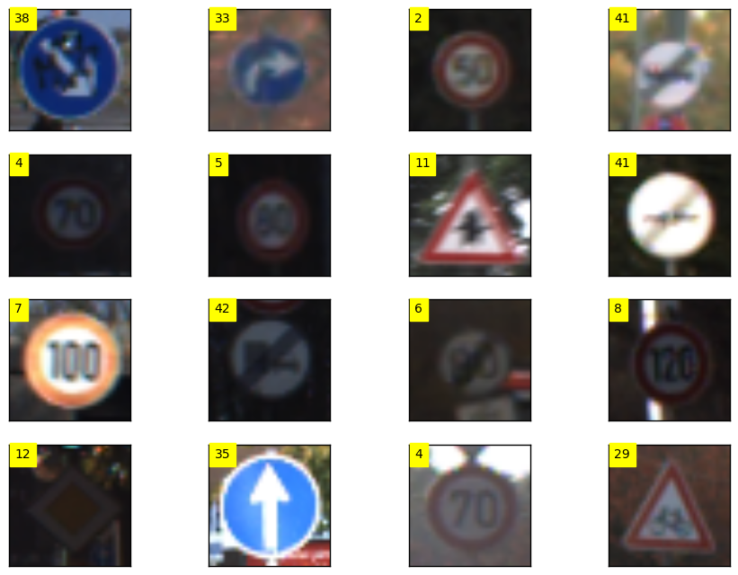

```python
#Plot Random Images.
def pltRandImages(ImgArray,ImgLabels,Rows=2):
    plt.figure(figsize=(11,8))
    pltIndex=0;
    ImgIndex=0;
    gs=gridspec.GridSpec(Rows,Rows)
    random.setstate(RandState)
    ImgIndex=random.sample(range(len(ImgArray)),Rows*Rows)
    for i in range (0,Rows*Rows):
        if(pltIndex>Rows-1):
            pltIndex=0
        ax=plt.subplot(gs[int(i/Rows),pltIndex])
        ax.set_xticks([])
        ax.set_yticks([])
        ax.set_aspect('equal')
        ax.text(1,3,str(ImgLabels[ImgIndex[i]]),backgroundcolor='yellow')
        plt.imshow(ImgArray[ImgIndex[i]])
        pltIndex=pltIndex+1
pltRandImages(TrainFeatures,TrainLabels,4)
```

[figure not shown]

```python
#Plotting one sign from each class
plt.figure(figsize=(11,80))
gs1=gridspec.GridSpec(NumClasses,1)
for i in range(0,NumClasses):
    ax1=plt.subplot(gs1[i,0])
    SignIndex=np.where(TrainLabels==i)
    ax1.imshow(TrainFeatures[SignIndex[0][100]])
    ax1.text(40,15,Labels[i])
    ax1.set_xticks([])
    ax1.set_yticks([])
```

## Step 2: Design and Test a Model Architecture

### Question 1

*Describe the techniques used to preprocess the data.*

Data Augmentation.

Pre Processing

Images were first adjusted for global constrast using histogram equalization. Then local contrast equaliztion is done using contrast limited adaptive histogram equalization.

### 1. Augmenting Training Data

```python
GenShape=(TotalNewData2Gen,32,32,3) #Shape of array to hold generated data
TrainFeaturesGen=np.zeros(GenShape,TrainFeatures.dtype)     #Array to hold generated images
TrainLabelsGen=np.zeros(TotalNewData2Gen,TrainLabels.dtype) #Array to hold generated labels

# Generate to be generated number of random index from each class
RandImgIndex=[]
Count=0
for i in range(0,NumClasses):
    RandImgIndex.append(np.random.randint(Count,Count+ClassList[i],ToGenNum[i]))
    Count=Count+ClassList[i]

#Generating Augmented Data by Rotating, Scaling and Changing Positions
#Values are from [1]
IndexCount=0
for i in range(0,NumClasses):
    print("Generating "+str(ToGenNum[i])+" "+str(Labels[i][1])+" features and labels")
    for j in range(0,ToGenNum[i]):
        Image=TrainFeatures[RandImgIndex[i][j]]
        #Rotation
        MaxRotAngle=15
        rows,cols,chnls=Image.shape
        RotMatrix=cv2.getRotationMatrix2D((rows/2,cols/2),random.uniform(-MaxRotAngle,MaxRotAngle),1)
        Image=cv2.warpAffine(Image,RotMatrix,(rows,cols))
        #Translation
        TransMatrix=np.float32([[1,0,random.uniform(-2,2)],[0,1,random.uniform(-2,2)]])
        Image=cv2.warpAffine(Image,TransMatrix,(rows,cols))
        #Scale
        #Image=cv2.resize(Image,None,fx=random.uniform(0.9,1.1),fy=random.uniform(0.9,1.1),interpolation=cv2.INTER_CUBIC)
        TrainFeaturesGen[IndexCount]=Image
        TrainLabelsGen[IndexCount]=i
        IndexCount=IndexCount+1
#Booleans to prevent doing accumulation or pre processing being done multiple times
DataAccDone=False    #Data Accumulation Done
PreProcessDone=False #Pre Processing Done
ValSplitDone=False
```

```
Generating 2040 Speed limit (20km/h) features and labels
Generating 30 Speed limit (30km/h) features and labels
Generating 0 Speed limit (50km/h) features and labels
Generating 840 Speed limit (60km/h) features and labels
Generating 270 Speed limit (70km/h) features and labels
Generating 390 Speed limit (80km/h) features and labels
Generating 1830 End of speed limit (80km/h) features and labels
Generating 810 Speed limit (100km/h) features and labels
Generating 840 Speed limit (120km/h) features and labels
Generating 780 No passing features and labels
Generating 240 No passing for vechiles over 3.5 metric tons features and labels
Generating 930 Right-of-way at the next intersection features and labels
Generating 150 Priority road features and labels
Generating 90 Yield features and labels
Generating 1470 Stop features and labels
Generating 1620 No vechiles features and labels
Generating 1830 Vechiles over 3.5 metric tons prohibited features and labels
Generating 1140 No entry features and labels
Generating 1050 General caution features and labels
Generating 2040 Dangerous curve to the left features and labels
Generating 1890 Dangerous curve to the right features and labels
Generating 1920 Double curve features and labels
Generating 1860 Bumpy road features and labels
Generating 1740 Slippery road features and labels
Generating 1980 Road narrows on the right features and labels
Generating 750 Road work features and labels
Generating 1650 Traffic signals features and labels
Generating 2010 Pedestrians features and labels
Generating 1710 Children crossing features and labels
Generating 1980 Bicycles crossing features and labels
Generating 1800 Beware of ice/snow features and labels
Generating 1470 Wild animals crossing features and labels
Generating 2010 End of all speed and passing limits features and labels
Generating 1561 Turn right ahead features and labels
Generating 1830 Turn left ahead features and labels
Generating 1050 Ahead only features and labels
Generating 1860 Go straight or right features and labels
Generating 2040 Go straight or left features and labels
Generating 180 Keep right features and labels
Generating 1950 Keep left features and labels
Generating 1890 Roundabout mandatory features and labels
Generating 2010 End of no passing features and labels
Generating 2010 End of no passing by vechiles over 3.5 metric tons features and labels
```

```
Data Accumulation Started
Data Accumulation Done
```

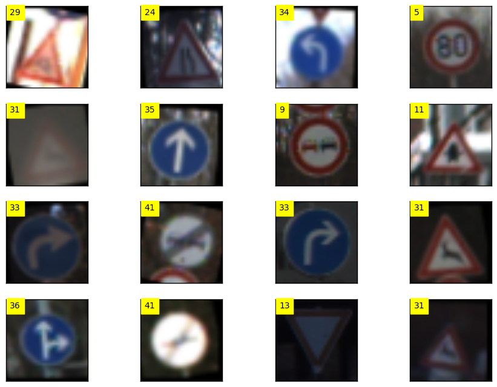

```python
#Accumulating Generated Data with Original Data
if(DataAccDone==False):
    print("Data Accumulation Started")
    TrainFeatures=np.append(TrainFeatures,TrainFeaturesGen,axis=0)
    TrainLabels=np.append(TrainLabels,TrainLabelsGen)
    DataAccDone=True
    print("Data Accumulation Done")
assert(TrainFeatures.shape[0]==TotalDataSize)
pltRandImages(TrainFeatures,TrainLabels,4)
```

### 2. Pre Processing Data

```python
#Pre Processing all the Images now
def preProcess(Img):
    Image=Img
    #Converting into Greyscale
    Image=cv2.cvtColor(Image,cv2.COLOR_BGR2GRAY)
    #Global Histogram Equilization
    Image=cv2.equalizeHist(Image)
    #Local Histogram Equilization
    clahe=cv2.createCLAHE(clipLimit=2.0, tileGridSize=(8,8))
    Image=clahe.apply(Image)
    return Image
#Pre Processing Training Image
if(PreProcessDone==False):
    print("Pre Processing Data Started")
    #TrainFeaturesPP=np.zeros(TrainFeatures.shape,TrainFeatures.dtype)
    TrainFeaturesPP=np.zeros(shape=[TotalDataSize,32,32],dtype=TrainFeatures.dtype)
    #TestFeaturesPP=np.zeros(TestFeatures.shape,TrainFeatures.dtype)
    TestFeaturesPP=np.zeros(shape=[TestFeatures.shape[0],32,32],dtype=TrainFeatures.dtype)
    for i in range(0,len(TrainFeatures)):
        TrainFeaturesPP[i]=preProcess(TrainFeatures[i])
    for i in range(0,len(TestFeatures)):
        TestFeaturesPP[i]=preProcess(TestFeatures[i])
    PreProcessDone=True
    print("Pre Processing Done")
```

```
Pre Processing Data Started
Pre Processing Done
```

```python
#Plotting Training Images after pre-processing
#pltRandImages(TrainFeaturesPP,TrainLabels,4)
```

### Question 2

*Describe how you set up the training, validation and testing data for your model. If you generated additional data, why?*

**Answer:** 25% of training dataset is set aside for validation. Test Dataset is left as is.

### Splitting into Validation and Training Sets

```python
#Splitting into Train and Validation Sets
ValSize=0.25 #25%
if(ValSplitDone==False):
    TrainFeaturesPP, ValFeaturesPP, TrainLabels, ValLabels = train_test_split(
     TrainFeaturesPP,TrainLabels, test_size=ValSize, random_state=2)
    ValSplitDone=True
assert((ValFeaturesPP.shape[0]+TrainFeaturesPP.shape[0])==TotalDataSize)
```

```python
#Convert Labels into One hot encoded Labels
def LabelEncoder(Labels,NumLabels):
    """Takes in Normal labels and returns onehot encoded labels"""
    Encoder=OneHotEncoder()
    Encoder.fit(np.arange(NumLabels).reshape(-1,1))
    EncodedLabels=Encoder.transform(Labels.reshape(-1,1)).toarray()
    return EncodedLabels
TrainLabelsOHE=LabelEncoder(TrainLabels,NumClasses)
ValLabelsOHE  =LabelEncoder(ValLabels,NumClasses)
TestLabelsOHE =LabelEncoder(TestLabels,NumClasses)
```

### Question 3

*What does your final architecture look like? (Type of model, layers, sizes, connectivity, etc.) For reference on how to build a deep neural network using TensorFlow, see Deep Neural Network in TensorFlow from the classroom.*

**Answer:** Architecture of the network is as follows

[output not shown]

### Network

```python
#Helper Functions for CNN Layers
wname1=0
wname2=100
def CreateConvLayer(input,NumChnls,FilSize,NumFils,Stride=1,pooling=True):
    global wname1
    #Create shape of filter
    FilterShape=[FilSize,FilSize,NumChnls,NumFils]
    #Create variables for weights and Biases
    wname1=wname1+1
    Weights=tf.get_variable("Weights"+str(wname1),
                            shape=FilterShape,initializer=tf.contrib.layers.xavier_initializer())
    Biases=tf.Variable(tf.constant(0.05,shape=[NumFils]))
    #Convolution Output
    ConvOpt=tf.nn.conv2d(input=input,filter=Weights,strides=[1,Stride,Stride,1],padding='SAME')
    #Add ConvOpt to Biases
    LayerOpt=tf.nn.bias_add(ConvOpt,Biases)
    #MaxPooling
    if(pooling==True):
        LayerOpt=tf.nn.max_pool(LayerOpt,[1,2,2,1],[1,2,2,1],'SAME')
    #Perform Relu
    LayerOpt=tf.nn.relu(LayerOpt)
    return LayerOpt,Weights
#Flatten Layer to input to Fully Connected Layer
def FlattenLayer(layer):
    LayerShape=layer.get_shape()
    NumFeatures =LayerShape[1:4].num_elements()
    LayerFlat=tf.reshape(layer,[-1,NumFeatures])
    return LayerFlat,NumFeatures
#Fully Connected Layer
def CreateFCLayer(input,NumInputs,NumOutputs,relu=True):
    global wname2
    #Weight Shape
    WShape=[NumInputs,NumOutputs]
    #Create Variables for Weights and Biases
    wname2=wname2+1
    Weights=tf.get_variable("Weights"+str(wname2),
                            shape=WShape,initializer=tf.contrib.layers.xavier_initializer())
    Biases=tf.Variable(tf.constant(0.05,shape=[NumOutputs]))
    #Calculate FC
    FCLayer=tf.matmul(input,Weights)+Biases
    if(relu==True):
        FCLayer=tf.nn.relu(FCLayer)
    return FCLayer, Weights
```

```python
def MyCNN(x,DropVal):
    FilterSize=[5,3,3]
    NumFilters=[16,64,64]
    FCSize=[1024,1024,256,128]
    #Layer1
    L1Conv, L1ConvWeight=CreateConvLayer(x,1,FilterSize[0],NumFilters[0])
    L1Conv=tf.nn.lrn(L1Conv,depth_radius=2,bias=1.0,alpha=2e-05,beta=0.75)
    #Layer2
    L2Conv, L2ConvWeight =CreateConvLayer(L1Conv,NumFilters[0],FilterSize[1],NumFilters[1])
    L2Conv=tf.nn.lrn(L2Conv,depth_radius=2,bias=1.0,alpha=2e-05,beta=0.75)
    #Layer3
    L3Conv, L3ConvWeight =CreateConvLayer(L2Conv,NumFilters[1],FilterSize[2],NumFilters[2])
    #Flatten
    FCFlat, NumFeatures=FlattenLayer(L3Conv)
    #FC1
    FC1,FC1W=CreateFCLayer(FCFlat,NumFeatures,FCSize[0])
    FC1=tf.nn.dropout(FC1,DropVal)
    FC2,FC2W=CreateFCLayer(FC1,FCSize[0],FCSize[1])
    FC2=tf.nn.dropout(FC2,DropVal)
    FC3,FC3W=CreateFCLayer(FC2,FCSize[1],FCSize[2])
    FC3=tf.nn.dropout(FC3,DropVal)
    FC4,FC4W=CreateFCLayer(FC3,FCSize[2],FCSize[3])
    FC5,FC5W=CreateFCLayer(FC4,FCSize[3],NumClasses,relu=False)
    return L1ConvWeight,L2ConvWeight,L3ConvWeight,FC1W,FC2W,FC3W,FC4W,FC5W,FC5
```

```python
#PlaceHolder for Image
ImgPHFlat=tf.placeholder(tf.float32,[None,32,32])
ImgPHRS=tf.reshape(ImgPHFlat,[-1,32,32,1])
#Placeholders for Labels
LabelPH_OHE  =tf.placeholder(tf.float32,[None,NumClasses])
LabelPH_Plain=tf.placeholder(tf.float32,[None])
#Placeholder for avoiding dropout during inference
DropVal1=tf.placeholder(tf.float32)
```

```python
#Running through network
L1ConvWeight,L2ConvWeight,L3ConvWeight,FC1W,FC2W,FC3W,FC4W,FC5W,NetworkOpt=MyCNN(ImgPHRS,DropVal=DropVal1)
#Applying Softmax to predict
ClassPredOHE = tf.nn.softmax(NetworkOpt)
#Selecting the highest probability to get normal label
ClassPred    = tf.argmax(ClassPredOHE, dimension=1)
#Casting
ClassPred    = tf.cast(ClassPred,tf.float32)
```

[output not shown]

```python
#Optimization
L2RegularVal=(tf.nn.l2_loss(L1ConvWeight))+(tf.nn.l2_loss(L2ConvWeight))+(tf.nn.l2_loss(L3ConvWeight))+(tf.nn.l2_loss(FC1W))+(tf.nn.l2_loss(FC2W))+(tf.nn.l2_loss(FC3W))+(tf.nn.l2_loss(FC4W))+(tf.nn.l2_loss(FC5W))
CrossEntorpy = tf.nn.softmax_cross_entropy_with_logits(logits=NetworkOpt,labels=LabelPH_OHE)
Cost = tf.reduce_mean(CrossEntorpy)+(L2RegularVal*1e-5)
Optimizer = tf.train.AdamOptimizer(learning_rate=1e-4).minimize(Cost)
```

```python
#Accuracy
CorrectPred = tf.equal(ClassPred,LabelPH_Plain)
Accuracy = tf.reduce_mean(tf.cast(CorrectPred, tf.float32))
```

```python
#TensorFlow Save
Saver = tf.train.Saver()
SaveDir='Checkpoints/'
#Create Savedir if it doesnt exist
if not os.path.exists(SaveDir):
    os.makedirs(SaveDir)
SavePath = SaveDir + 'BestVal'
```

### Question 4

*How did you train your model? (Type of optimizer, batch size, epochs, hyperparameters, etc.)*

**Answer:**

Epochs=30000

Learning Rate=1*e-4

L2 Regularization Beta=1e-5

Dropout=0.5

Xavier weight initialization is used for better convergence of the model. Dropout is used to generalize network more. L2 Regularization is applied for penalizing large weights. Adam optimizer is used for optimization.

### Training and Optimization

```python
#Initialization
session=tf.Session()
session.run(tf.global_variables_initializer())
```

```python
#Session Saver
saver=tf.train.Saver()
#saver.restore(sess=session,save_path=SaveDir)
```

```python
TotalRuns=0
BestValAcc=0.0
def TrainCNN(NumRuns,BatchSize):
    print("Training Started")
    global TotalRuns
    global BestValAcc
    #Keep track of time to report at last
    StartTime=time.time()
    for i in range(TotalRuns,TotalRuns+NumRuns):
        TotalRuns=TotalRuns+1
        #Choose BatchSize number of indices randomly without replacement
        TrainIndex=np.random.choice(len(TrainFeaturesPP),BatchSize,replace=False)
        #Dictionary for Optimizer
        TrainDict= {
            ImgPHFlat:TrainFeaturesPP[TrainIndex,:],
            DropVal1:0.5,
            LabelPH_OHE:TrainLabelsOHE[TrainIndex,:]
        }
        #Running Optimizer
        session.run(Optimizer,TrainDict)
        #Dictionary for Calculating Training accuracy of this batch
        TrainAccDict={
            ImgPHFlat:TrainFeaturesPP[TrainIndex,:],
            DropVal1:1,
            LabelPH_OHE:TrainLabelsOHE[TrainIndex,:],
            LabelPH_Plain:TrainLabels[TrainIndex]
        }
        #For Every 500 Iterations give accuracy
        if ((TotalRuns%500==0) or (i==(NumRuns-1))):
            #Calculate Training Accuracy
            TrainAcc=session.run(Accuracy,TrainAccDict)
            ValAcc=CalAcc("Val",BatchSize)
            TestAcc=CalAcc("Test",BatchSize)
            #Saving good stuff
            if (ValAcc>=BestValAcc):
                BestValAcc=ValAcc
                saver.save(sess=session,save_path=SaveDir)
                ImpStr="*"
            else:
                ImpStr=" "
            msg = "Iter: {0:>6}, Train-Batch Accuracy: {1:>6.1%}, Validation Acc: {2:>6.1%} {3} Test Acc:{4:>4.1%}"
            print(msg.format(i + 1,TrainAcc,ValAcc,ImpStr,TestAcc))
    #Ending and reporting results
    EndTime=time.time()
    TimeDelta=EndTime-StartTime
    print("Total Time ="+str(timedelta(seconds=int(round(TimeDelta)))))
    #return TrainAccList,ValAccList,TrainCostList
```

```python
def CalAcc(Type="Val",BatchSize=100):
    AccuracyVal=0
    if(Type=="Val"):
        ValIndex=np.random.choice(len(ValFeaturesPP),BatchSize,replace=False)
        ValAccDict={
            ImgPHFlat:ValFeaturesPP[ValIndex,:],
            DropVal1:1,
            LabelPH_OHE:ValLabelsOHE[ValIndex,:],
            LabelPH_Plain:ValLabels[ValIndex]
        }
        AccuracyVal=session.run(Accuracy,ValAccDict)
    if(Type=="Test"):
        TestIndex=np.random.choice(len(TestFeaturesPP),BatchSize,replace=False)
        TestAccDict={
            ImgPHFlat:TestFeaturesPP[TestIndex,:],
            DropVal1:1,
            LabelPH_OHE:TestLabelsOHE[TestIndex,:],
            LabelPH_Plain:TestLabels[TestIndex]
        }
        AccuracyVal=session.run(Accuracy,TestAccDict)
    return AccuracyVal
```

```python
TrainCNN(20000,400)
```

```
Training Started
Iter:  10500, Train-Batch Accuracy:  99.7%, Validation Acc:  97.7%   Test Acc:95.2%
Iter:  11000, Train-Batch Accuracy: 100.0%, Validation Acc:  97.7%   Test Acc:94.0%
Iter:  11500, Train-Batch Accuracy: 100.0%, Validation Acc:  99.2%   Test Acc:94.0%
Iter:  12000, Train-Batch Accuracy: 100.0%, Validation Acc:  98.0%   Test Acc:95.2%
Iter:  12500, Train-Batch Accuracy: 100.0%, Validation Acc:  99.0%   Test Acc:94.7%
Iter:  13000, Train-Batch Accuracy: 100.0%, Validation Acc:  98.0%   Test Acc:94.5%
Iter:  13500, Train-Batch Accuracy: 100.0%, Validation Acc:  98.2%   Test Acc:95.0%
Iter:  14000, Train-Batch Accuracy: 100.0%, Validation Acc:  97.7%   Test Acc:95.2%
Iter:  14500, Train-Batch Accuracy: 100.0%, Validation Acc:  99.2%   Test Acc:94.7%
Iter:  15000, Train-Batch Accuracy: 100.0%, Validation Acc:  97.7%   Test Acc:94.7%
Iter:  15500, Train-Batch Accuracy: 100.0%, Validation Acc:  99.0%   Test Acc:95.7%
Iter:  16000, Train-Batch Accuracy: 100.0%, Validation Acc:  98.7%   Test Acc:95.5%
Iter:  16500, Train-Batch Accuracy: 100.0%, Validation Acc:  98.5%   Test Acc:93.0%
Iter:  17000, Train-Batch Accuracy: 100.0%, Validation Acc:  99.5% * Test Acc:94.7%
Iter:  17500, Train-Batch Accuracy: 100.0%, Validation Acc:  98.7%   Test Acc:96.5%
Iter:  18000, Train-Batch Accuracy: 100.0%, Validation Acc:  99.2%   Test Acc:95.7%
Iter:  18500, Train-Batch Accuracy: 100.0%, Validation Acc:  98.7%   Test Acc:95.0%
Iter:  19000, Train-Batch Accuracy: 100.0%, Validation Acc:  98.2%   Test Acc:95.0%
Iter:  19500, Train-Batch Accuracy: 100.0%, Validation Acc:  99.5% * Test Acc:95.0%
Iter:  20000, Train-Batch Accuracy: 100.0%, Validation Acc:  98.7%   Test Acc:95.5%
Iter:  20500, Train-Batch Accuracy: 100.0%, Validation Acc:  98.7%   Test Acc:95.2%
Iter:  21000, Train-Batch Accuracy: 100.0%, Validation Acc:  98.7%   Test Acc:95.7%
Iter:  21500, Train-Batch Accuracy: 100.0%, Validation Acc:  99.5% * Test Acc:96.2%
Iter:  22000, Train-Batch Accuracy: 100.0%, Validation Acc:  99.0%   Test Acc:97.7%
Iter:  22500, Train-Batch Accuracy: 100.0%, Validation Acc:  97.7%   Test Acc:95.0%
Iter:  23000, Train-Batch Accuracy: 100.0%, Validation Acc:  99.0%   Test Acc:96.2%
Iter:  23500, Train-Batch Accuracy: 100.0%, Validation Acc:  98.0%   Test Acc:95.2%
Iter:  24000, Train-Batch Accuracy: 100.0%, Validation Acc:  99.2%   Test Acc:93.3%
Iter:  24500, Train-Batch Accuracy: 100.0%, Validation Acc:  98.0%   Test Acc:94.2%
Iter:  25000, Train-Batch Accuracy: 100.0%, Validation Acc:  98.2%   Test Acc:93.5%
Iter:  25500, Train-Batch Accuracy: 100.0%, Validation Acc:  99.2%   Test Acc:96.5%
Iter:  26000, Train-Batch Accuracy: 100.0%, Validation Acc:  98.2%   Test Acc:94.2%
Iter:  26500, Train-Batch Accuracy: 100.0%, Validation Acc:  97.5%   Test Acc:96.5%
Iter:  27000, Train-Batch Accuracy: 100.0%, Validation Acc:  98.2%   Test Acc:96.7%
Iter:  27500, Train-Batch Accuracy: 100.0%, Validation Acc:  98.5%   Test Acc:95.5%
Iter:  28000, Train-Batch Accuracy: 100.0%, Validation Acc:  99.2%   Test Acc:96.2%
Iter:  28500, Train-Batch Accuracy: 100.0%, Validation Acc:  98.5%   Test Acc:96.5%
Iter:  29000, Train-Batch Accuracy: 100.0%, Validation Acc:  98.2%   Test Acc:95.2%
Iter:  29500, Train-Batch Accuracy: 100.0%, Validation Acc:  99.5% * Test Acc:95.0%
Iter:  30000, Train-Batch Accuracy: 100.0%, Validation Acc:  99.2%   Test Acc:96.2%
Total Time =0:05:55
```

```python
saver.restore(sess=session,save_path=SaveDir)
CalAcc("Test",2000)
```

```
0.96250004
```

### Question 5

*What approach did you take in coming up with a solution to this problem?*

**Answer:**

I first started with LeNet architecture with 3x3x32 filters. While network performed good on validation set, it never crossed 87% on test set. Then I started using AlexNet-->VGG-->Googlenet which gave me >90% on test images but never performed well on test images. Then CS231 taught by Andrej Karpathy opened my eyes to importance of weight initialization, regularization and overfitting. I started from LeNet again with dropout and regularization which started giving me >90% test accuracy as well as good results on test images. I added one more convolution and full connected layer for better representation.

## Step 3: Test a Model on New Images

Take several pictures of traffic signs that you find on the web or around you (at least five), and run them through your classifier on your computer to produce example results. The classifier might not recognize some local signs but it could prove interesting nonetheless.

You may find `signnames.csv` useful as it contains mappings from the class id (integer) to the actual sign name.

```python
def ClassifyImg(ImgName):
    dim=(32,32)
    Image=cv2.imread(ImgName)
    Image1=Image
    #Resize image to 32x32
    Image=cv2.resize(Image,dim,cv2.INTER_CUBIC)
    #Preprocess the image like training data
    Image=preProcess(Image)
    TestDict={
            ImgPHFlat:[Image,Image],
            DropVal1:1,
            LabelPH_OHE:TestLabelsOHE
        }
    Val=session.run(ClassPred,TestDict)
    Val=Val.astype(int)
    fig=plt.figure()
    ax1=fig.add_subplot(121)
    ax1.imshow(cv2.cvtColor(Image1,cv2.COLOR_BGR2RGB))
    plt.title("Predicted: "+Labels[Val[0]][1])
    ax1.set_xticks([])
    ax1.set_yticks([])
    #Predict the top5 predictions done by network
    Top5=tf.nn.top_k(ClassPredOHE,5)
    Top5Pred=session.run([ClassPredOHE,Top5],TestDict)
    Top5Prob=sorted(Top5Pred[1][0][0])
    #Plot the predictions
    ax2=fig.add_subplot(122)
    ax2.barh(np.arange(5),Top5Prob,color='green',ecolor='black')
    for i in range(0,5):
        ax2.text(0.05,(0.85-(i/5)),Labels[Top5Pred[1][1][0][i]],transform=ax2.transAxes)
    ax2.set_xticks([])
    ax2.set_yticks([])
```

### Question 6

*Choose five candidate images of traffic signs and provide them in the report. Are there any particular qualities of the image(s) that might make classification difficult? It would be helpful to plot the images in the notebook.*

[figure not shown]

[figure not shown]

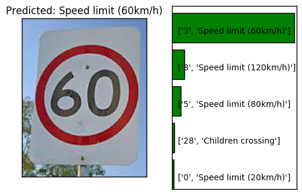

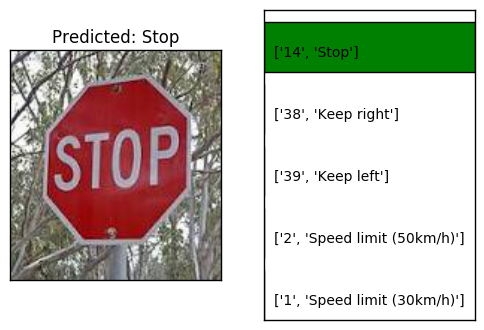

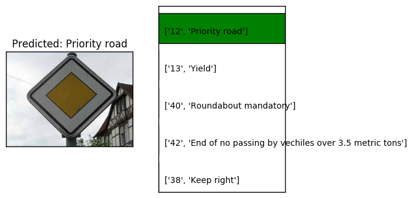

[figure not shown]

```python
ClassifyImg("G0_Round.jpg")
ClassifyImg("G1_50mph.jpg")
ClassifyImg("G2_60mph.jpg")
ClassifyImg("G3_Stop1.jpg")
ClassifyImg("G4_PRoad.jpg")
ClassifyImg("G6_Stop.png")
```

### Testing on American Road Signs

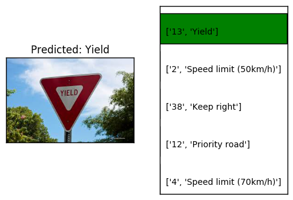

[figure not shown]

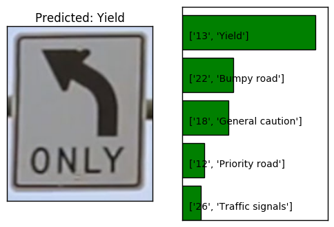

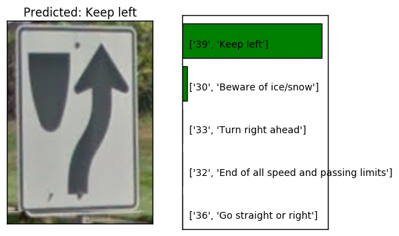

[figure not shown]

```python
ClassifyImg("1_Yeild.jpg")
ClassifyImg("2_noenter.jpg")
ClassifyImg("3_LeftOnly.png")
ClassifyImg("4_Divider.png")
ClassifyImg("5_RoundAbout.jpg")
```

### Question 7

*Is your model able to perform equally well on captured pictures or a live camera stream when compared to testing on the dataset?*

**Answer:**

While it is doing OK on similar german signs, it cannot classify if the picture of the sign contains any other data like pole or an another sign.

### Question 8

*Use the model's softmax probabilities to visualize the **certainty** of its predictions, [`tf.nn.top_k`](https://www.tensorflow.org/versions/r0.11/api_docs/python/nn.html#top_k) could prove helpful here. Which predictions is the model certain of? Uncertain? If the model was incorrect in its initial prediction, does the correct prediction appear in the top k? (k should be 5 at most)*

**Answer:**

Illustrated above

### Question 9

*If necessary, provide documentation for how an interface was built for your model to load and classify newly-acquired images.*

**Answer:**

ClassifyImg(Image Filename) takes and image and returns the image class along with top 5 predictions for the image

## Reference

I have used the following resources to help me with the project

1 . https://github.com/Hvass-Labs/TensorFlow-Tutorials for code snippets for printing CNN statistics, functions for network layers

2 . http://cs231n.github.io/convolutional-networks/ for various ideas used in the project